# Risk Factor Analysis

## Outcome Variable

**Outcome Variable:** whz

## Predictor Variables

**Intervention Variable:** impsan

**Adjustment Set:**

- arm
- sex
- W_mage
- meducyrs
- feducyrs
- hhwealth_quart
- hfoodsec
- W_mhtcm
- W_mwtkg
- W_mbmi
- W_nrooms
- W_nchldlt5
- W_parity
- impfloor
- safeh20
- delta_W_mage
- delta_meducyrs
- delta_feducyrs
- delta_hhwealth_quart
- delta_hfoodsec
- delta_W_mhtcm
- delta_W_mwtkg
- delta_W_mbmi
- delta_W_nrooms
- delta_W_nchldlt5
- delta_W_parity
- delta_impfloor
- delta_safeh20

## Stratifying Variables

The analysis was stratified on these variable(s):

- agecat
- studyid
- country

## Data Summary

| agecat | studyid | country | impsan | n_cell | n | outcome_variable |
| --- | --- | --- | --- | --- | --- | --- |
| Birth | ki0047075b-MAL-ED | BANGLADESH | 1 | 168 | 201 | whz |
| Birth | ki0047075b-MAL-ED | BANGLADESH | 0 | 33 | 201 | whz |
| Birth | ki0047075b-MAL-ED | BRAZIL | 1 | 56 | 57 | whz |
| Birth | ki0047075b-MAL-ED | BRAZIL | 0 | 1 | 57 | whz |
| Birth | ki0047075b-MAL-ED | INDIA | 1 | 14 | 39 | whz |
| Birth | ki0047075b-MAL-ED | INDIA | 0 | 25 | 39 | whz |
| Birth | ki0047075b-MAL-ED | NEPAL | 1 | 24 | 25 | whz |
| Birth | ki0047075b-MAL-ED | NEPAL | 0 | 1 | 25 | whz |
| Birth | ki0047075b-MAL-ED | PERU | 1 | 50 | 203 | whz |
| Birth | ki0047075b-MAL-ED | PERU | 0 | 153 | 203 | whz |
| Birth | ki0047075b-MAL-ED | SOUTH AFRICA | 1 | 0 | 94 | whz |
| Birth | ki0047075b-MAL-ED | SOUTH AFRICA | 0 | 94 | 94 | whz |
| Birth | ki0047075b-MAL-ED | TANZANIA, UNITED REPUBLIC OF | 1 | 0 | 110 | whz |
| Birth | ki0047075b-MAL-ED | TANZANIA, UNITED REPUBLIC OF | 0 | 110 | 110 | whz |
| Birth | ki1017093-NIH-Birth | BANGLADESH | 1 | 222 | 575 | whz |
| Birth | ki1017093-NIH-Birth | BANGLADESH | 0 | 353 | 575 | whz |
| Birth | ki1017093b-PROVIDE | BANGLADESH | 1 | 43 | 45 | whz |
| Birth | ki1017093b-PROVIDE | BANGLADESH | 0 | 2 | 45 | whz |
| Birth | ki1017093c-NIH-Crypto | BANGLADESH | 1 | 610 | 696 | whz |
| Birth | ki1017093c-NIH-Crypto | BANGLADESH | 0 | 86 | 696 | whz |
| Birth | ki1114097-CONTENT | PERU | 1 | 1 | 2 | whz |
| Birth | ki1114097-CONTENT | PERU | 0 | 1 | 2 | whz |
| Birth | ki1135781-COHORTS | GUATEMALA | 1 | 43 | 449 | whz |
| Birth | ki1135781-COHORTS | GUATEMALA | 0 | 406 | 449 | whz |
| Birth | ki1135781-COHORTS | INDIA | 1 | 1685 | 4461 | whz |
| Birth | ki1135781-COHORTS | INDIA | 0 | 2776 | 4461 | whz |
| Birth | ki1135781-COHORTS | PHILIPPINES | 1 | 177 | 1126 | whz |
| Birth | ki1135781-COHORTS | PHILIPPINES | 0 | 949 | 1126 | whz |
| Birth | kiGH5241-JiVitA-3 | BANGLADESH | 1 | 12413 | 17991 | whz |
| Birth | kiGH5241-JiVitA-3 | BANGLADESH | 0 | 5578 | 17991 | whz |

[output cut: 70 more lines]

The following strata were considered:

- agecat: 24 months, studyid: ki0047075b-MAL-ED, country: BANGLADESH
- agecat: 24 months, studyid: ki0047075b-MAL-ED, country: BRAZIL
- agecat: 24 months, studyid: ki0047075b-MAL-ED, country: INDIA
- agecat: 24 months, studyid: ki0047075b-MAL-ED, country: NEPAL
- agecat: 24 months, studyid: ki0047075b-MAL-ED, country: PERU
- agecat: 24 months, studyid: ki0047075b-MAL-ED, country: SOUTH AFRICA
- agecat: 24 months, studyid: ki0047075b-MAL-ED, country: TANZANIA, UNITED REPUBLIC OF
- agecat: 24 months, studyid: ki1017093-NIH-Birth, country: BANGLADESH
- agecat: 24 months, studyid: ki1017093b-PROVIDE, country: BANGLADESH
- agecat: 24 months, studyid: ki1017093c-NIH-Crypto, country: BANGLADESH
- agecat: 24 months, studyid: ki1114097-CONTENT, country: PERU
- agecat: 24 months, studyid: ki1135781-COHORTS, country: GUATEMALA
- agecat: 24 months, studyid: ki1135781-COHORTS, country: INDIA
- agecat: 24 months, studyid: ki1135781-COHORTS, country: PHILIPPINES
- agecat: 24 months, studyid: ki1148112-LCNI-5, country: MALAWI
- agecat: 24 months, studyid: kiGH5241-JiVitA-3, country: BANGLADESH
- agecat: 24 months, studyid: kiGH5241-JiVitA-4, country: BANGLADESH
- agecat: 6 months, studyid: ki0047075b-MAL-ED, country: BANGLADESH
- agecat: 6 months, studyid: ki0047075b-MAL-ED, country: BRAZIL
- agecat: 6 months, studyid: ki0047075b-MAL-ED, country: INDIA
- agecat: 6 months, studyid: ki0047075b-MAL-ED, country: NEPAL
- agecat: 6 months, studyid: ki0047075b-MAL-ED, country: PERU
- agecat: 6 months, studyid: ki0047075b-MAL-ED, country: SOUTH AFRICA
- agecat: 6 months, studyid: ki0047075b-MAL-ED, country: TANZANIA, UNITED REPUBLIC OF
- agecat: 6 months, studyid: ki1017093-NIH-Birth, country: BANGLADESH
- agecat: 6 months, studyid: ki1017093b-PROVIDE, country: BANGLADESH
- agecat: 6 months, studyid: ki1017093c-NIH-Crypto, country: BANGLADESH
- agecat: 6 months, studyid: ki1114097-CONTENT, country: PERU
- agecat: 6 months, studyid: ki1135781-COHORTS, country: GUATEMALA
- agecat: 6 months, studyid: ki1135781-COHORTS, country: INDIA
- agecat: 6 months, studyid: ki1135781-COHORTS, country: PHILIPPINES
- agecat: 6 months, studyid: ki1148112-LCNI-5, country: MALAWI
- agecat: 6 months, studyid: kiGH5241-JiVitA-3, country: BANGLADESH
- agecat: 6 months, studyid: kiGH5241-JiVitA-4, country: BANGLADESH
- agecat: Birth, studyid: ki0047075b-MAL-ED, country: BANGLADESH
- agecat: Birth, studyid: ki0047075b-MAL-ED, country: BRAZIL
- agecat: Birth, studyid: ki0047075b-MAL-ED, country: INDIA
- agecat: Birth, studyid: ki0047075b-MAL-ED, country: NEPAL
- agecat: Birth, studyid: ki0047075b-MAL-ED, country: PERU
- agecat: Birth, studyid: ki0047075b-MAL-ED, country: SOUTH AFRICA
- agecat: Birth, studyid: ki0047075b-MAL-ED, country: TANZANIA, UNITED REPUBLIC OF
- agecat: Birth, studyid: ki1017093-NIH-Birth, country: BANGLADESH
- agecat: Birth, studyid: ki1017093b-PROVIDE, country: BANGLADESH
- agecat: Birth, studyid: ki1017093c-NIH-Crypto, country: BANGLADESH
- agecat: Birth, studyid: ki1114097-CONTENT, country: PERU
- agecat: Birth, studyid: ki1135781-COHORTS, country: GUATEMALA
- agecat: Birth, studyid: ki1135781-COHORTS, country: INDIA
- agecat: Birth, studyid: ki1135781-COHORTS, country: PHILIPPINES
- agecat: Birth, studyid: kiGH5241-JiVitA-3, country: BANGLADESH
- agecat: Birth, studyid: kiGH5241-JiVitA-4, country: BANGLADESH

### Dropped Strata

Some strata were dropped due to rare outcomes:

- agecat: Birth, studyid: ki0047075b-MAL-ED, country: BRAZIL
- agecat: Birth, studyid: ki0047075b-MAL-ED, country: NEPAL
- agecat: Birth, studyid: ki0047075b-MAL-ED, country: SOUTH AFRICA
- agecat: Birth, studyid: ki0047075b-MAL-ED, country: TANZANIA, UNITED REPUBLIC OF
- agecat: Birth, studyid: ki1017093b-PROVIDE, country: BANGLADESH
- agecat: Birth, studyid: ki1114097-CONTENT, country: PERU
- agecat: 6 months, studyid: ki0047075b-MAL-ED, country: BRAZIL
- agecat: 6 months, studyid: ki0047075b-MAL-ED, country: NEPAL
- agecat: 6 months, studyid: ki0047075b-MAL-ED, country: SOUTH AFRICA
- agecat: 6 months, studyid: ki0047075b-MAL-ED, country: TANZANIA, UNITED REPUBLIC OF
- agecat: 6 months, studyid: ki1017093b-PROVIDE, country: BANGLADESH
- agecat: 6 months, studyid: ki1148112-LCNI-5, country: MALAWI
- agecat: 24 months, studyid: ki0047075b-MAL-ED, country: BRAZIL
- agecat: 24 months, studyid: ki0047075b-MAL-ED, country: NEPAL
- agecat: 24 months, studyid: ki0047075b-MAL-ED, country: SOUTH AFRICA
- agecat: 24 months, studyid: ki0047075b-MAL-ED, country: TANZANIA, UNITED REPUBLIC OF
- agecat: 24 months, studyid: ki1017093b-PROVIDE, country: BANGLADESH
- agecat: 24 months, studyid: ki1148112-LCNI-5, country: MALAWI

## Methods Detail

We’re interested in the causal parameters $E[Y_a]$ for all values of $a \in \mathcal{A}$. These parameters represent the mean outcome if, possibly contrary to fact, we intervened to set all units to have $A=a$. Under the randomization and positivity assumptions, these are identified by the statistical parameters $\psi_a=E_W[E_{Y|A,W}(Y|A=a,W)]$. In addition, we’re interested in the mean of $Y$, $E[Y]$ under no intervention (the observed mean). We will estimate these parameters by using SuperLearner to fit the relevant likelihood factors – $E_{Y|A,W}(Y|A=a,W)$ and $p(A=a|W)$, and then updating our likelihood fit using a joint TMLE.

For unadjusted analyses ($W=\{\}$), initial likelihoods were estimated using Lrnr_glm to estimate the simple $E(Y|A)$ and Lrnr_mean to estimate $p(A)$. For adjusted analyses, a small library containing Lrnr_glmnet, Lrnr_xgboost, and Lrnr_mean was used.

Having estimated these parameters, we will then use the delta method to estimate relative risks and attributable risks relative to a prespecified baseline level of $A$.

# Results Detail

## Results Plots

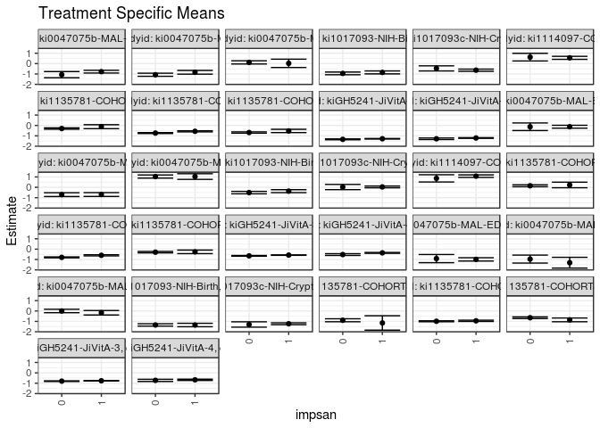

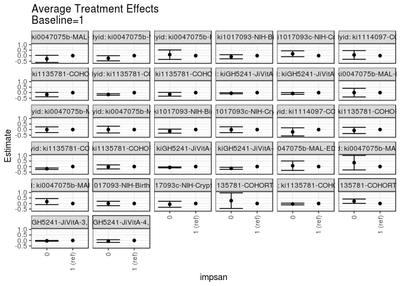

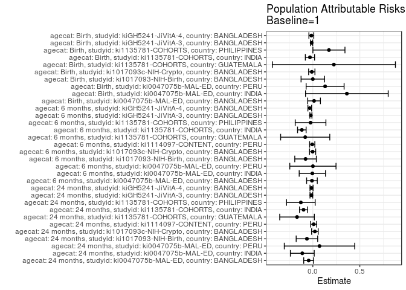

## Results Table

### Parameter: TSM

| agecat | studyid | country | intervention_level | baseline_level | estimate | ci_lower | ci_upper |
| --- | --- | --- | --- | --- | --- | --- | --- |
| Birth | ki0047075b-MAL-ED | BANGLADESH | 1 | NA | -0.9860563 | -1.1480329 | -0.8240797 |
| Birth | ki0047075b-MAL-ED | BANGLADESH | 0 | NA | -0.9098519 | -1.3045990 | -0.5151049 |
| Birth | ki0047075b-MAL-ED | INDIA | 1 | NA | -1.3063237 | -1.8250696 | -0.7875777 |
| Birth | ki0047075b-MAL-ED | INDIA | 0 | NA | -0.9584881 | -1.3428128 | -0.5741634 |
| Birth | ki0047075b-MAL-ED | PERU | 1 | NA | -0.1688535 | -0.3845238 | 0.0468168 |
| Birth | ki0047075b-MAL-ED | PERU | 0 | NA | 0.0021620 | -0.1646630 | 0.1689869 |
| Birth | ki1017093-NIH-Birth | BANGLADESH | 1 | NA | -1.3499461 | -1.5163550 | -1.1835373 |
| Birth | ki1017093-NIH-Birth | BANGLADESH | 0 | NA | -1.3457078 | -1.4608040 | -1.2306117 |
| Birth | ki1017093c-NIH-Crypto | BANGLADESH | 1 | NA | -1.2291976 | -1.3187018 | -1.1396934 |
| Birth | ki1017093c-NIH-Crypto | BANGLADESH | 0 | NA | -1.2992214 | -1.5575974 | -1.0408453 |
| Birth | ki1135781-COHORTS | GUATEMALA | 1 | NA | -1.1533594 | -1.8471232 | -0.4595956 |
| Birth | ki1135781-COHORTS | GUATEMALA | 0 | NA | -0.8931841 | -1.0359825 | -0.7503858 |
| Birth | ki1135781-COHORTS | INDIA | 1 | NA | -0.9465947 | -1.0077982 | -0.8853912 |
| Birth | ki1135781-COHORTS | INDIA | 0 | NA | -0.9890072 | -1.0338139 | -0.9442004 |
| Birth | ki1135781-COHORTS | PHILIPPINES | 1 | NA | -0.8553645 | -1.0372230 | -0.6735060 |
| Birth | ki1135781-COHORTS | PHILIPPINES | 0 | NA | -0.6493524 | -0.7301347 | -0.5685702 |
| Birth | kiGH5241-JiVitA-3 | BANGLADESH | 1 | NA | -0.7651664 | -0.7883254 | -0.7420075 |
| Birth | kiGH5241-JiVitA-3 | BANGLADESH | 0 | NA | -0.8006110 | -0.8332283 | -0.7679936 |
| Birth | kiGH5241-JiVitA-4 | BANGLADESH | 1 | NA | -0.6724959 | -0.7319605 | -0.6130313 |
| Birth | kiGH5241-JiVitA-4 | BANGLADESH | 0 | NA | -0.7262740 | -0.8302048 | -0.6223432 |
| 6 months | ki0047075b-MAL-ED | BANGLADESH | 1 | NA | -0.1239837 | -0.2645863 | 0.0166190 |
| 6 months | ki0047075b-MAL-ED | BANGLADESH | 0 | NA | -0.1253259 | -0.4895812 | 0.2389295 |
| 6 months | ki0047075b-MAL-ED | INDIA | 1 | NA | -0.6967610 | -0.8796909 | -0.5138312 |
| 6 months | ki0047075b-MAL-ED | INDIA | 0 | NA | -0.7073697 | -0.8884132 | -0.5263263 |
| 6 months | ki0047075b-MAL-ED | PERU | 1 | NA | 1.0364337 | 0.7656391 | 1.3072284 |
| 6 months | ki0047075b-MAL-ED | PERU | 0 | NA | 1.0365795 | 0.8861646 | 1.1869943 |
| 6 months | ki1017093-NIH-Birth | BANGLADESH | 1 | NA | -0.3700178 | -0.5112518 | -0.2287838 |
| 6 months | ki1017093-NIH-Birth | BANGLADESH | 0 | NA | -0.5097680 | -0.6274542 | -0.3920817 |
| 6 months | ki1017093c-NIH-Crypto | BANGLADESH | 1 | NA | 0.0358214 | -0.0478973 | 0.1195401 |
| 6 months | ki1017093c-NIH-Crypto | BANGLADESH | 0 | NA | 0.0250820 | -0.2273742 | 0.2775382 |
| 6 months | ki1114097-CONTENT | PERU | 1 | NA | 1.0747447 | 0.9526611 | 1.1968282 |
| 6 months | ki1114097-CONTENT | PERU | 0 | NA | 0.8638813 | 0.5142096 | 1.2135529 |
| 6 months | ki1135781-COHORTS | GUATEMALA | 1 | NA | 0.2268950 | -0.0426955 | 0.4964855 |
| 6 months | ki1135781-COHORTS | GUATEMALA | 0 | NA | 0.1491726 | 0.0565732 | 0.2417719 |
| 6 months | ki1135781-COHORTS | INDIA | 1 | NA | -0.5935732 | -0.6485202 | -0.5386262 |
| 6 months | ki1135781-COHORTS | INDIA | 0 | NA | -0.7916663 | -0.8340293 | -0.7493033 |
| 6 months | ki1135781-COHORTS | PHILIPPINES | 1 | NA | -0.2589160 | -0.4290578 | -0.0887742 |
| 6 months | ki1135781-COHORTS | PHILIPPINES | 0 | NA | -0.2914215 | -0.3619554 | -0.2208876 |
| 6 months | kiGH5241-JiVitA-3 | BANGLADESH | 1 | NA | -0.5725433 | -0.5954610 | -0.5496255 |
| 6 months | kiGH5241-JiVitA-3 | BANGLADESH | 0 | NA | -0.6468722 | -0.6845376 | -0.6092067 |
| 6 months | kiGH5241-JiVitA-4 | BANGLADESH | 1 | NA | -0.3572125 | -0.3987581 | -0.3156669 |
| 6 months | kiGH5241-JiVitA-4 | BANGLADESH | 0 | NA | -0.5226145 | -0.6075595 | -0.4376694 |
| 24 months | ki0047075b-MAL-ED | BANGLADESH | 1 | NA | -0.7749546 | -0.9060309 | -0.6438783 |
| 24 months | ki0047075b-MAL-ED | BANGLADESH | 0 | NA | -1.0648664 | -1.3633648 | -0.7663680 |
| 24 months | ki0047075b-MAL-ED | INDIA | 1 | NA | -0.8370017 | -1.0162343 | -0.6577690 |
| 24 months | ki0047075b-MAL-ED | INDIA | 0 | NA | -1.0737133 | -1.2228271 | -0.9245996 |
| 24 months | ki0047075b-MAL-ED | PERU | 1 | NA | 0.0261982 | -0.3741249 | 0.4265214 |
| 24 months | ki0047075b-MAL-ED | PERU | 0 | NA | 0.1190512 | -0.0368816 | 0.2749840 |
| 24 months | ki1017093-NIH-Birth | BANGLADESH | 1 | NA | -0.8488207 | -0.9911222 | -0.7065192 |
| 24 months | ki1017093-NIH-Birth | BANGLADESH | 0 | NA | -0.9437237 | -1.0739098 | -0.8135376 |
| 24 months | ki1017093c-NIH-Crypto | BANGLADESH | 1 | NA | -0.6335060 | -0.7376181 | -0.5293939 |
| 24 months | ki1017093c-NIH-Crypto | BANGLADESH | 0 | NA | -0.4607079 | -0.7060576 | -0.2153581 |
| 24 months | ki1114097-CONTENT | PERU | 1 | NA | 0.5574772 | 0.4121089 | 0.7028455 |
| 24 months | ki1114097-CONTENT | PERU | 0 | NA | 0.6242247 | 0.2556717 | 0.9927777 |
| 24 months | ki1135781-COHORTS | GUATEMALA | 1 | NA | -0.1180774 | -0.3074950 | 0.0713402 |
| 24 months | ki1135781-COHORTS | GUATEMALA | 0 | NA | -0.2950576 | -0.3578991 | -0.2322161 |
| 24 months | ki1135781-COHORTS | INDIA | 1 | NA | -0.5622130 | -0.6164360 | -0.5079901 |
| 24 months | ki1135781-COHORTS | INDIA | 0 | NA | -0.7330848 | -0.7755093 | -0.6906602 |
| 24 months | ki1135781-COHORTS | PHILIPPINES | 1 | NA | -0.5289892 | -0.6887573 | -0.3692211 |
| 24 months | ki1135781-COHORTS | PHILIPPINES | 0 | NA | -0.6807893 | -0.7436741 | -0.6179046 |
| 24 months | kiGH5241-JiVitA-3 | BANGLADESH | 1 | NA | -1.2815363 | -1.3095762 | -1.2534965 |
| 24 months | kiGH5241-JiVitA-3 | BANGLADESH | 0 | NA | -1.3372491 | -1.3815120 | -1.2929862 |
| 24 months | kiGH5241-JiVitA-4 | BANGLADESH | 1 | NA | -1.2092950 | -1.2442983 | -1.1742918 |
| 24 months | kiGH5241-JiVitA-4 | BANGLADESH | 0 | NA | -1.2835496 | -1.3578422 | -1.2092571 |

### Parameter: E(Y)

| agecat | studyid | country | intervention_level | baseline_level | estimate | ci_lower | ci_upper |
| --- | --- | --- | --- | --- | --- | --- | --- |
| Birth | ki0047075b-MAL-ED | BANGLADESH | NA | NA | -0.9728358 | -1.1217009 | -0.8239707 |
| Birth | ki0047075b-MAL-ED | INDIA | NA | NA | -0.9441026 | -1.2397919 | -0.6484132 |
| Birth | ki0047075b-MAL-ED | PERU | NA | NA | -0.0381281 | -0.1669868 | 0.0907307 |
| Birth | ki1017093-NIH-Birth | BANGLADESH | NA | NA | -1.3499217 | -1.4444634 | -1.2553801 |
| Birth | ki1017093c-NIH-Crypto | BANGLADESH | NA | NA | -1.2402802 | -1.3249395 | -1.1556208 |
| Birth | ki1135781-COHORTS | GUATEMALA | NA | NA | -0.9294432 | -1.0701697 | -0.7887168 |
| Birth | ki1135781-COHORTS | INDIA | NA | NA | -0.9771733 | -1.0119896 | -0.9423570 |
| Birth | ki1135781-COHORTS | PHILIPPINES | NA | NA | -0.6841030 | -0.7582767 | -0.6099293 |
| Birth | kiGH5241-JiVitA-3 | BANGLADESH | NA | NA | -0.7777528 | -0.7967725 | -0.7587330 |
| Birth | kiGH5241-JiVitA-4 | BANGLADESH | NA | NA | -0.6882498 | -0.7406539 | -0.6358456 |
| 6 months | ki0047075b-MAL-ED | BANGLADESH | NA | NA | -0.1333333 | -0.2623761 | -0.0042906 |
| 6 months | ki0047075b-MAL-ED | INDIA | NA | NA | -0.7018062 | -0.8289790 | -0.5746333 |
| 6 months | ki0047075b-MAL-ED | PERU | NA | NA | 1.0372972 | 0.9141109 | 1.1604836 |
| 6 months | ki1017093-NIH-Birth | BANGLADESH | NA | NA | -0.4474038 | -0.5378167 | -0.3569909 |
| 6 months | ki1017093c-NIH-Crypto | BANGLADESH | NA | NA | 0.0336790 | -0.0458848 | 0.1132428 |
| 6 months | ki1114097-CONTENT | PERU | NA | NA | 1.0684318 | 0.9515274 | 1.1853362 |
| 6 months | ki1135781-COHORTS | GUATEMALA | NA | NA | 0.1458511 | 0.0589571 | 0.2327450 |
| 6 months | ki1135781-COHORTS | INDIA | NA | NA | -0.7104855 | -0.7428053 | -0.6781657 |
| 6 months | ki1135781-COHORTS | PHILIPPINES | NA | NA | -0.2830286 | -0.3471028 | -0.2189545 |
| 6 months | kiGH5241-JiVitA-3 | BANGLADESH | NA | NA | -0.5931476 | -0.6127125 | -0.5735828 |
| 6 months | kiGH5241-JiVitA-4 | BANGLADESH | NA | NA | -0.3901595 | -0.4274150 | -0.3529041 |
| 24 months | ki0047075b-MAL-ED | BANGLADESH | NA | NA | -0.8192925 | -0.9412667 | -0.6973182 |
| 24 months | ki0047075b-MAL-ED | INDIA | NA | NA | -0.9490222 | -1.0651720 | -0.8328724 |
| 24 months | ki0047075b-MAL-ED | PERU | NA | NA | 0.0972406 | -0.0271085 | 0.2215898 |
| 24 months | ki1017093-NIH-Birth | BANGLADESH | NA | NA | -0.9115790 | -1.0095022 | -0.8136559 |
| 24 months | ki1017093c-NIH-Crypto | BANGLADESH | NA | NA | -0.6115706 | -0.7075788 | -0.5155624 |
| 24 months | ki1114097-CONTENT | PERU | NA | NA | 0.5668293 | 0.4302437 | 0.7034148 |
| 24 months | ki1135781-COHORTS | GUATEMALA | NA | NA | -0.2861905 | -0.3461594 | -0.2262216 |
| 24 months | ki1135781-COHORTS | INDIA | NA | NA | -0.6606874 | -0.6938402 | -0.6275347 |
| 24 months | ki1135781-COHORTS | PHILIPPINES | NA | NA | -0.6564149 | -0.7144543 | -0.5983756 |
| 24 months | kiGH5241-JiVitA-3 | BANGLADESH | NA | NA | -1.2970418 | -1.3203361 | -1.2737475 |
| 24 months | kiGH5241-JiVitA-4 | BANGLADESH | NA | NA | -1.2231776 | -1.2550332 | -1.1913220 |

### Parameter: ATE

| agecat | studyid | country | intervention_level | baseline_level | estimate | ci_lower | ci_upper |
| --- | --- | --- | --- | --- | --- | --- | --- |
| Birth | ki0047075b-MAL-ED | BANGLADESH | 1 | 1 | 0.0000000 | 0.0000000 | 0.0000000 |
| Birth | ki0047075b-MAL-ED | BANGLADESH | 0 | 1 | 0.0762043 | -0.3512009 | 0.5036096 |
| Birth | ki0047075b-MAL-ED | INDIA | 1 | 1 | 0.0000000 | 0.0000000 | 0.0000000 |
| Birth | ki0047075b-MAL-ED | INDIA | 0 | 1 | 0.3478356 | -0.3132590 | 1.0089302 |
| Birth | ki0047075b-MAL-ED | PERU | 1 | 1 | 0.0000000 | 0.0000000 | 0.0000000 |
| Birth | ki0047075b-MAL-ED | PERU | 0 | 1 | 0.1710155 | -0.1021789 | 0.4442098 |
| Birth | ki1017093-NIH-Birth | BANGLADESH | 1 | 1 | 0.0000000 | 0.0000000 | 0.0000000 |
| Birth | ki1017093-NIH-Birth | BANGLADESH | 0 | 1 | 0.0042383 | -0.1986667 | 0.2071434 |
| Birth | ki1017093c-NIH-Crypto | BANGLADESH | 1 | 1 | 0.0000000 | 0.0000000 | 0.0000000 |
| Birth | ki1017093c-NIH-Crypto | BANGLADESH | 0 | 1 | -0.0700238 | -0.3432486 | 0.2032010 |
| Birth | ki1135781-COHORTS | GUATEMALA | 1 | 1 | 0.0000000 | 0.0000000 | 0.0000000 |
| Birth | ki1135781-COHORTS | GUATEMALA | 0 | 1 | 0.2601753 | -0.4481927 | 0.9685433 |
| Birth | ki1135781-COHORTS | INDIA | 1 | 1 | 0.0000000 | 0.0000000 | 0.0000000 |
| Birth | ki1135781-COHORTS | INDIA | 0 | 1 | -0.0424125 | -0.1181688 | 0.0333439 |
| Birth | ki1135781-COHORTS | PHILIPPINES | 1 | 1 | 0.0000000 | 0.0000000 | 0.0000000 |
| Birth | ki1135781-COHORTS | PHILIPPINES | 0 | 1 | 0.2060120 | 0.0074111 | 0.4046129 |
| Birth | kiGH5241-JiVitA-3 | BANGLADESH | 1 | 1 | 0.0000000 | 0.0000000 | 0.0000000 |
| Birth | kiGH5241-JiVitA-3 | BANGLADESH | 0 | 1 | -0.0354445 | -0.0732308 | 0.0023418 |
| Birth | kiGH5241-JiVitA-4 | BANGLADESH | 1 | 1 | 0.0000000 | 0.0000000 | 0.0000000 |
| Birth | kiGH5241-JiVitA-4 | BANGLADESH | 0 | 1 | -0.0537781 | -0.1719229 | 0.0643668 |
| 6 months | ki0047075b-MAL-ED | BANGLADESH | 1 | 1 | 0.0000000 | 0.0000000 | 0.0000000 |
| 6 months | ki0047075b-MAL-ED | BANGLADESH | 0 | 1 | -0.0013422 | -0.3924212 | 0.3897368 |
| 6 months | ki0047075b-MAL-ED | INDIA | 1 | 1 | 0.0000000 | 0.0000000 | 0.0000000 |
| 6 months | ki0047075b-MAL-ED | INDIA | 0 | 1 | -0.0106087 | -0.2710331 | 0.2498158 |
| 6 months | ki0047075b-MAL-ED | PERU | 1 | 1 | 0.0000000 | 0.0000000 | 0.0000000 |
| 6 months | ki0047075b-MAL-ED | PERU | 0 | 1 | 0.0001457 | -0.3105784 | 0.3108699 |
| 6 months | ki1017093-NIH-Birth | BANGLADESH | 1 | 1 | 0.0000000 | 0.0000000 | 0.0000000 |
| 6 months | ki1017093-NIH-Birth | BANGLADESH | 0 | 1 | -0.1397502 | -0.3239700 | 0.0444697 |
| 6 months | ki1017093c-NIH-Crypto | BANGLADESH | 1 | 1 | 0.0000000 | 0.0000000 | 0.0000000 |
| 6 months | ki1017093c-NIH-Crypto | BANGLADESH | 0 | 1 | -0.0107394 | -0.2767623 | 0.2552836 |
| 6 months | ki1114097-CONTENT | PERU | 1 | 1 | 0.0000000 | 0.0000000 | 0.0000000 |
| 6 months | ki1114097-CONTENT | PERU | 0 | 1 | -0.2108634 | -0.5836656 | 0.1619388 |
| 6 months | ki1135781-COHORTS | GUATEMALA | 1 | 1 | 0.0000000 | 0.0000000 | 0.0000000 |
| 6 months | ki1135781-COHORTS | GUATEMALA | 0 | 1 | -0.0777224 | -0.3628518 | 0.2074070 |
| 6 months | ki1135781-COHORTS | INDIA | 1 | 1 | 0.0000000 | 0.0000000 | 0.0000000 |
| 6 months | ki1135781-COHORTS | INDIA | 0 | 1 | -0.1980931 | -0.2673807 | -0.1288055 |
| 6 months | ki1135781-COHORTS | PHILIPPINES | 1 | 1 | 0.0000000 | 0.0000000 | 0.0000000 |
| 6 months | ki1135781-COHORTS | PHILIPPINES | 0 | 1 | -0.0325055 | -0.2171586 | 0.1521477 |
| 6 months | kiGH5241-JiVitA-3 | BANGLADESH | 1 | 1 | 0.0000000 | 0.0000000 | 0.0000000 |
| 6 months | kiGH5241-JiVitA-3 | BANGLADESH | 0 | 1 | -0.0743289 | -0.1162783 | -0.0323795 |
| 6 months | kiGH5241-JiVitA-4 | BANGLADESH | 1 | 1 | 0.0000000 | 0.0000000 | 0.0000000 |
| 6 months | kiGH5241-JiVitA-4 | BANGLADESH | 0 | 1 | -0.1654019 | -0.2590450 | -0.0717589 |
| 24 months | ki0047075b-MAL-ED | BANGLADESH | 1 | 1 | 0.0000000 | 0.0000000 | 0.0000000 |
| 24 months | ki0047075b-MAL-ED | BANGLADESH | 0 | 1 | -0.2899118 | -0.6167912 | 0.0369675 |
| 24 months | ki0047075b-MAL-ED | INDIA | 1 | 1 | 0.0000000 | 0.0000000 | 0.0000000 |
| 24 months | ki0047075b-MAL-ED | INDIA | 0 | 1 | -0.2367117 | -0.4706648 | -0.0027585 |
| 24 months | ki0047075b-MAL-ED | PERU | 1 | 1 | 0.0000000 | 0.0000000 | 0.0000000 |
| 24 months | ki0047075b-MAL-ED | PERU | 0 | 1 | 0.0928530 | -0.3368629 | 0.5225689 |
| 24 months | ki1017093-NIH-Birth | BANGLADESH | 1 | 1 | 0.0000000 | 0.0000000 | 0.0000000 |
| 24 months | ki1017093-NIH-Birth | BANGLADESH | 0 | 1 | -0.0949030 | -0.2849095 | 0.0951035 |
| 24 months | ki1017093c-NIH-Crypto | BANGLADESH | 1 | 1 | 0.0000000 | 0.0000000 | 0.0000000 |
| 24 months | ki1017093c-NIH-Crypto | BANGLADESH | 0 | 1 | 0.1727981 | -0.0922726 | 0.4378688 |
| 24 months | ki1114097-CONTENT | PERU | 1 | 1 | 0.0000000 | 0.0000000 | 0.0000000 |
| 24 months | ki1114097-CONTENT | PERU | 0 | 1 | 0.0667475 | -0.3301138 | 0.4636087 |
| 24 months | ki1135781-COHORTS | GUATEMALA | 1 | 1 | 0.0000000 | 0.0000000 | 0.0000000 |
| 24 months | ki1135781-COHORTS | GUATEMALA | 0 | 1 | -0.1769802 | -0.3770249 | 0.0230645 |
| 24 months | ki1135781-COHORTS | INDIA | 1 | 1 | 0.0000000 | 0.0000000 | 0.0000000 |
| 24 months | ki1135781-COHORTS | INDIA | 0 | 1 | -0.1708717 | -0.2392938 | -0.1024496 |
| 24 months | ki1135781-COHORTS | PHILIPPINES | 1 | 1 | 0.0000000 | 0.0000000 | 0.0000000 |
| 24 months | ki1135781-COHORTS | PHILIPPINES | 0 | 1 | -0.1518001 | -0.3238391 | 0.0202390 |
| 24 months | kiGH5241-JiVitA-3 | BANGLADESH | 1 | 1 | 0.0000000 | 0.0000000 | 0.0000000 |
| 24 months | kiGH5241-JiVitA-3 | BANGLADESH | 0 | 1 | -0.0557128 | -0.1066258 | -0.0047997 |
| 24 months | kiGH5241-JiVitA-4 | BANGLADESH | 1 | 1 | 0.0000000 | 0.0000000 | 0.0000000 |
| 24 months | kiGH5241-JiVitA-4 | BANGLADESH | 0 | 1 | -0.0742546 | -0.1550038 | 0.0064946 |

### Parameter: PAR

| agecat | studyid | country | intervention_level | baseline_level | estimate | ci_lower | ci_upper |
| --- | --- | --- | --- | --- | --- | --- | --- |
| Birth | ki0047075b-MAL-ED | BANGLADESH | 1 | NA | 0.0132205 | -0.0543067 | 0.0807476 |
| Birth | ki0047075b-MAL-ED | INDIA | 1 | NA | 0.3622211 | -0.0776384 | 0.8020806 |
| Birth | ki0047075b-MAL-ED | PERU | 1 | NA | 0.1307254 | -0.0712803 | 0.3327311 |
| Birth | ki1017093-NIH-Birth | BANGLADESH | 1 | NA | 0.0000244 | -0.1252992 | 0.1253480 |
| Birth | ki1017093c-NIH-Crypto | BANGLADESH | 1 | NA | -0.0110826 | -0.0446309 | 0.0224657 |
| Birth | ki1135781-COHORTS | GUATEMALA | 1 | NA | 0.2239162 | -0.4310592 | 0.8788916 |
| Birth | ki1135781-COHORTS | INDIA | 1 | NA | -0.0305786 | -0.0797365 | 0.0185793 |
| Birth | ki1135781-COHORTS | PHILIPPINES | 1 | NA | 0.1712614 | 0.0006506 | 0.3418723 |
| Birth | kiGH5241-JiVitA-3 | BANGLADESH | 1 | NA | -0.0125863 | -0.0240119 | -0.0011607 |
| Birth | kiGH5241-JiVitA-4 | BANGLADESH | 1 | NA | -0.0157539 | -0.0417058 | 0.0101980 |
| 6 months | ki0047075b-MAL-ED | BANGLADESH | 1 | NA | -0.0093497 | -0.0660452 | 0.0473459 |
| 6 months | ki0047075b-MAL-ED | INDIA | 1 | NA | -0.0050451 | -0.1450986 | 0.1350083 |
| 6 months | ki0047075b-MAL-ED | PERU | 1 | NA | 0.0008635 | -0.2450098 | 0.2467367 |
| 6 months | ki1017093-NIH-Birth | BANGLADESH | 1 | NA | -0.0773860 | -0.1921008 | 0.0373288 |
| 6 months | ki1017093c-NIH-Crypto | BANGLADESH | 1 | NA | -0.0021424 | -0.0348459 | 0.0305611 |
| 6 months | ki1114097-CONTENT | PERU | 1 | NA | -0.0063129 | -0.0338426 | 0.0212168 |
| 6 months | ki1135781-COHORTS | GUATEMALA | 1 | NA | -0.0810439 | -0.3424520 | 0.1803642 |
| 6 months | ki1135781-COHORTS | INDIA | 1 | NA | -0.1169123 | -0.1624425 | -0.0713820 |
| 6 months | ki1135781-COHORTS | PHILIPPINES | 1 | NA | -0.0241126 | -0.1874274 | 0.1392022 |
| 6 months | kiGH5241-JiVitA-3 | BANGLADESH | 1 | NA | -0.0206044 | -0.0315663 | -0.0096425 |
| 6 months | kiGH5241-JiVitA-4 | BANGLADESH | 1 | NA | -0.0329470 | -0.0524842 | -0.0134099 |
| 24 months | ki0047075b-MAL-ED | BANGLADESH | 1 | NA | -0.0443379 | -0.0968816 | 0.0082059 |
| 24 months | ki0047075b-MAL-ED | INDIA | 1 | NA | -0.1120206 | -0.2388038 | 0.0147627 |
| 24 months | ki0047075b-MAL-ED | PERU | 1 | NA | 0.0710424 | -0.3036925 | 0.4457773 |
| 24 months | ki1017093-NIH-Birth | BANGLADESH | 1 | NA | -0.0627584 | -0.1771652 | 0.0516484 |
| 24 months | ki1017093c-NIH-Crypto | BANGLADESH | 1 | NA | 0.0219354 | -0.0131556 | 0.0570264 |
| 24 months | ki1114097-CONTENT | PERU | 1 | NA | 0.0093521 | -0.0225129 | 0.0412171 |
| 24 months | ki1135781-COHORTS | GUATEMALA | 1 | NA | -0.1681131 | -0.3522525 | 0.0160264 |
| 24 months | ki1135781-COHORTS | INDIA | 1 | NA | -0.0984744 | -0.1414926 | -0.0554562 |
| 24 months | ki1135781-COHORTS | PHILIPPINES | 1 | NA | -0.1274257 | -0.2798036 | 0.0249523 |
| 24 months | kiGH5241-JiVitA-3 | BANGLADESH | 1 | NA | -0.0155054 | -0.0301105 | -0.0009004 |
| 24 months | kiGH5241-JiVitA-4 | BANGLADESH | 1 | NA | -0.0138825 | -0.0301663 | 0.0024012 |